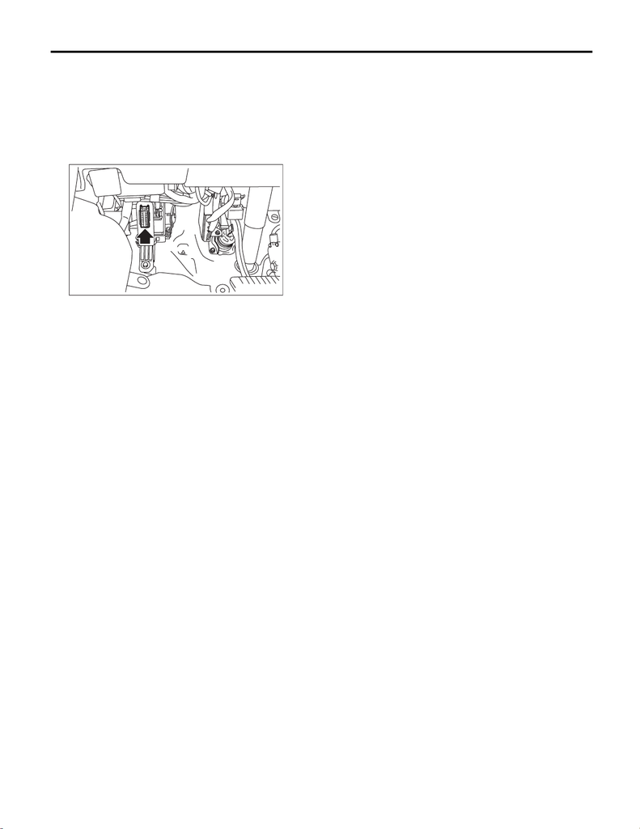

EN(w/o STI)(diag)-32

General Scan Tool

ENGINE (DIAGNOSTICS)

8. General Scan Tool

A: OPERATION

1. HOW TO USE GENERAL SCAN TOOL

1) Prepare a scan tool (general scan tool) required by SAE J1978.

2) Connect the general scan tool to data link connector located in the lower portion of the instrument panel

(on the driver’s side).

3) Using the general scan tool, call up each data. General scan tool functions consist of:

(1) MODE $01: Current powertrain diagnostic data

(2) MODE $02: Powertrain freeze frame data

(3) MODE $03: Emission-related powertrain DTC

(4) MODE $04: Clear/Reset emission-related diagnostic information

(5) MODE $06: Request on-board monitoring test results for intermittently monitored systems

(6) MODE $07: Request on-board monitoring test results for continuously monitored systems

(7) MODE $08: Request control for on-board system, test, and component

(8) MODE $09: Request vehicle information

4) Read out the data according to repair procedures. (For detailed operation procedure, refer to the general

scan tool operation manual.)

NOTE:

For details concerning DTC, refer to “List of Diagnostic Trouble Code (DTC)”. <Ref. to EN(w/o STI)(diag)-85,

List of Diagnostic Trouble Code (DTC).>

EN-09145

[figure not shown]

EN(w/o STI)(diag)-33

General Scan Tool

ENGINE (DIAGNOSTICS)

2. MODE $01 (CURRENT POWERTRAIN DIAGNOSTIC DATA)

Refer to data denoting the current operating condition of analog input/output, digital input/output or the pow-

ertrain system.

A list of the support data and PID (Parameter Identification) codes are shown in the following table.

NOTE:

Refer to general scan tool manufacturer’s operation manual to access current powertrain diagnostic data

(MODE $01).

PID Data Unit of measure

$01

Number of emission-related powertrain DTC, and malfunction indicator light status and diag-

nosis support information

—

$03 Fuel system control status —

$04 Calculated engine load value %

$05 Engine coolant temperature °C

$06 Short term fuel trim %

$07 Long term fuel trim %

$0B Intake manifold absolute pressure kPa

$0C Engine speed rpm

$0D Vehicle speed MPH

$0E Ignition timing advance °

$10 Intake air amount g/s

$11 Throttle valve absolute opening angle %

$13 Check whether oxygen sensor is installed. —

$15 Oxygen sensor output voltage and short term fuel trim associated with oxygen sensor V and %

$1C Supporting OBD system —

$1F Elapsed time after starting the engine sec

$21 Running distance after MIL turns on miles

$24 A/F value and A/F sensor output voltage – and V

$2C Target EGR %

$2D EGR error %

$2E Evaporative purge %

$2F Fuel level %

$30 Number of warm ups after DTC clear —

$31 Travel distance after DTC clear miles

$33 Barometric pressure kPa

$34 A/F value and A/F sensor output current – and mA

$3C Catalyst temperature °C

$41 Diagnostic monitor of each drive cycle —

$42 ECM power voltage V

$43 Absolute load %

$44 A/F target lambda —

$45 Relative throttle opening angle %

$46 Ambient temperature °C

$47 Absolute throttle opening angle 2 %

$49 Absolute accelerator opening angle 1 %

$4A Absolute accelerator opening angle 2 %

$4C Target throttle opening angle %

$4D Engine operation time during MIL on min

$4E Elapsed time after DTC clear min

$51 Fuel used —

$53 ELCM pressure kPa

$5A Relative accelerator opening angle %

$5C Engine oil temperature °C

$65 Neutral status —

$68 Intake air temperature °C

$6D Fuel pressure and target fuel pressure kPa

[figure not shown]

EN(w/o STI)(diag)-34

General Scan Tool

ENGINE (DIAGNOSTICS)

3. MODE $02 (POWERTRAIN FREEZE FRAME DATA)

Refer to data denoting the operating condition when trouble is detected by on-board diagnosis system.

A list of the support data and PID (Parameter Identification) codes are shown in the following table.

NOTE:

Refer to general scan tool manufacturer’s operation manual to access freeze frame data (MODE $02).

Refer to “List of Diagnostic Trouble Code (DTC)” for information about data denoting emission-related pow-

ertrain DTC. <Ref. to EN(w/o STI)(diag)-85, List of Diagnostic Trouble Code (DTC).>

PID Data Unit of measure

$02 DTC that caused freeze frame data to be stored —

$03 Fuel system control status —

$04 Calculated engine load value %

$05 Engine coolant temperature °C

$06 Short term fuel trim %

$07 Long term fuel trim %

$0B Intake manifold absolute pressure kPa

$0C Engine speed rpm

$0D Vehicle speed MPH

$0E Ignition timing advance °

$10 Intake air amount g/s

$11 Throttle valve absolute opening angle %

$13 Air fuel ratio sensor —

$15 Rear oxygen sensor voltage, compensation value V and %

$1C Supporting OBD system —

$1F Elapsed time after starting the engine sec

$2C Target EGR %

$2D EGR error %

$2E Evaporative purge %

$2F Fuel level %

$30 Number of warm ups after DTC clear Time

$33 Barometric pressure kPa

$42 ECM power voltage V

$43 Absolute load %

$44 A/F target lambda —

$45 Relative throttle opening angle %

$46 Ambient temperature °C

$47 Absolute throttle opening angle 2 %

$49 Absolute accelerator opening angle 1 %

$4A Absolute accelerator opening angle 2 %

$4C Target throttle opening angle %

$65 Neutral status —

$68 Intake air temperature °C

$6D Fuel pressure and target fuel pressure kPa

[figure not shown]

EN(w/o STI)(diag)-35

General Scan Tool

ENGINE (DIAGNOSTICS)

5. MODE $04 (CLEAR/RESET EMISSION-RELATED DIAGNOSTIC INFORMATION)

Refer to the mode used to clear or reset emission-related diagnostic information.

NOTE:

• Refer to the manufacturer’s operation manual for the general scan tool to clear the emission-related diag-

nostic information (MODE $04).

• Initial diagnosis of electronic throttle control is performed after memory clearance. Wait for 10 seconds or

more after turning the ignition switch to ON, and then start the engine.

6. MODE $06

Refer to diagnostic value of troubleshooting and data of test limit indicated on the support data bit sequence

table. A list of the support data is shown in the following table.

NOTE:

Some items are not displayed according to the specifications.

OBDMID TID SID Diagnostic item

$01

$84 $1E

A/F sensor range failure (Bank 1 Sensor 1)

$85 $1E

$86 $20

A/F sensor response failure (Bank 1 Sensor 1)

$91 $20

$92 $10

$A3 $20

$A4 $10

$AC $10

$AD $10

$AE $10

$AF $10

$CD $20

$CF $20

$DF $10

$02

$07 $0B

Oxygen sensor drop failure (Bank 1 Sensor 2)

$08 $0B

$05 $10

Oxygen sensor response failure (Bank 1 Sensor 2)$06 $10

$BD $10

$D1 $10

Oxygen sensor delay failure (Bank 1 Sensor 2)

$D2 $01

$21 $89 $20 Catalyst deterioration diagnosis (Bank 1)

$31 $8A $FD EGR system diagnosis

$35

$8B $9D

VVT monitor (Bank 1)

$8C $9D

$8D $9D

$8E $9D

$D3 $9D

$D4 $9D

$D5 $9D

$D6 $9D

[figure not shown]

EN(w/o STI)(diag)-36

General Scan Tool

ENGINE (DIAGNOSTICS)

8.MODE $08 (REQUEST CONTROL FOR ON-BOARD SYSTEM, TEST, AND COMPONENT)

Perform “Active Test” of the on-board system.

9. MODE $09

Refer to the data of the vehicle specification.

$8B $9D

VVT monitor (Bank 2)

$8C $9D

$8D $9D

$8E $9D

$D3 $9D

$D4 $9D

$D5 $9D

$D6 $9D

$3C

$96 $FE

Evaporative emission control system (0.02 inch leak)

$C1 $FE

$C2 $FE

$C3 $FE

$C4 $FE

$C5 $FE

$C6 $35

$C7 $FE

$C8 $FE

$C9 $FE

$CA $FE

$3D

$98 $FE Evaporative emission control system (purge flow)

$CB $35

ELCM purge flow

$CC $FE

$41 $9B $14 A/F sensor heater characteristics failure (Bank 1 Sensor 1)

$42 $A2 $24 Oxygen sensor heater characteristics failure (Bank 1 Sensor 2)

$A1

$0B $24

Misfire monitoring (all cylinders)

$0C $24

$A2

$0B $24

Misfire monitoring (#1 cylinder)

$0C $24

$A3

$0B $24

Misfire monitoring (#2 cylinder)

$0C $24

$A4

$0B $24

Misfire monitoring (#3 cylinder)

$0C $24

$A5

$0B $24

Misfire monitoring (#4 cylinder)

$0C $24

OBDMID TID SID Diagnostic item